# Test a Perceptual Phenomenon

### Analyzing the Stroop Effect

Perform the analysis in the space below. Remember to follow [the instructions](https://docs.google.com/document/d/1-OkpZLjG_kX9J6LIQ5IltsqMzVWjh36QpnP2RYpVdPU/pub?embedded=True) and review the [project rubric](https://review.udacity.com/#!/rubrics/71/view) before submitting. Once you've completed the analysis and write-up, download this file as a PDF or HTML file, upload that PDF/HTML into the workspace here (click on the orange Jupyter icon in the upper left then Upload), then use the Submit Project button at the bottom of this page. This will create a zip file containing both this .ipynb doc and the PDF/HTML doc that will be submitted for your project.

(1) What is the independent variable? What is the dependent variable?

The dependent variable is Duration (in seconds) to recognize color and text and

The independent variable is the Congruency of the color and text

(2) What is an appropriate set of hypotheses for this task? Specify your null and alternative hypotheses, and clearly define any notation used. Justify your choices.

The Null Hypotheses or H<sub>0</sub>  
is that the means of the populations from which the two samples were taken are equal

like this:  
H<sub>0</sub>:  
m<sub>1</sub> = m<sub>2</sub>

The Alternative Hypotheses or H<sub>1</sub>  
is that the means of the populations from which the two samples were taken are not equal

like that:  
H<sub>1</sub>: m<sub>1</sub> != m<sub>2</sub>

where  
m<sub>1</sub> is the first test mean (Congruent) and  
m<sub>2</sub> is the second test mean (Incongruent)

we will perform a paired t-test because the two groups are dependent,  
actually they are the same people making two different tests  
and also because the sample size is small (24 observations)  
and the poplation mean and standard deviation is missing  
that's a good reason for not using a Z-test for instance.

Assumptions:

1- the distribution of the samples means is normal  
2- the samples are randomly chosen and pairs withen the sample are independent

(3) Report some descriptive statistics regarding this dataset. Include at least one measure of central tendency and at least one measure of variability. The name of the data file is 'stroopdata.csv'.

```python
# Perform the analysis here
import pandas as pd
import numpy as np
from scipy import stats
import matplotlib.pyplot as plt
df = pd.read_csv("stroopdata.csv")
df.describe()
```

|  | Congruent | Incongruent |
| --- | --- | --- |
| count | 24.000000 | 24.000000 |
| mean | 14.051125 | 22.015917 |
| std | 3.559358 | 4.797057 |
| min | 8.630000 | 15.687000 |
| 25% | 11.895250 | 18.716750 |
| 50% | 14.356500 | 21.017500 |
| 75% | 16.200750 | 24.051500 |
| max | 22.328000 | 35.255000 |

We can see that the mean for Test1 (14.05) is less than that for Test2 (22.01)  
That is, Test2 takes longer time than Test1 on average

As for the standard deviation, it is (3.55) and (4.79) for Test1 and Test2 respectively  
Test2 results is a little more spreaded than Test1  
I think that is because in Test1 human nature is the same for percepting word written in the same color  
but percepting an Incongruent word and ink color can be harder and not every one will respond the same

(4) Provide one or two visualizations that show the distribution of the sample data. Write one or two sentences noting what you observe about the plot or plots.

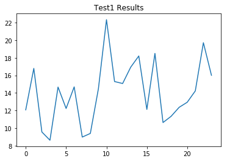

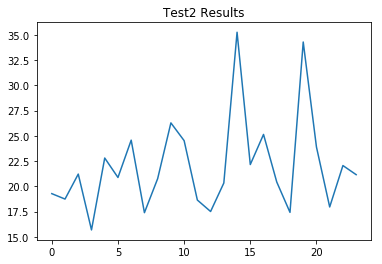

```python
# Build the visualizations here
% matplotlib inline

plt.plot(df["Congruent"])
plt.title("Test1 Results")
plt.show()

plt.plot(df["Incongruent"])
plt.title("Test2 Results")
plt.show()
```

The minimal time for Test2 is higher and reaches almost (15.5) seconds  
While the minimal time for Test1 is at (8.5) seconds  
That means minimum time almost doubled when the word condition changed  
and that tells us about the effect of this change on perception

(5) Now, perform the statistical test and report your results. What is your confidence level or Type I error associated with your test? What is your conclusion regarding the hypotheses you set up? Did the results match up with your expectations? **Hint:** Think about what is being measured on each individual, and what statistic best captures how an individual reacts in each environment.

```python
# Perform the statistical test here
T_test = stats.ttest_rel(df["Congruent"], df["Incongruent"])
T_test
```

```
Ttest_relResult(statistic=-8.020706944109957, pvalue=4.1030005857111781e-08)
```

As we can see, the p-value is too small and definitely is less than 0.05  
Hence, we will reject the Null hypotheses since the p-vale tells us that there is significant difference in means  
and as a result, there is significant change happened in perception when the word condition changed

(6) Optional: What do you think is responsible for the effects observed? Can you think of an alternative or similar task that would result in a similar effect? Some research about the problem will be helpful for thinking about these two questions!

I think it's human nature. our brains is trained to do regular jobs faster and without thinking  
and here a regular job is naming the color of a word when the word is written in the same color  
but an unusual job and mixing things up make our brains take more time to process the new and unusual situation

A similar task that would result in similar effect i think is when you read a sentence in reverse